# Tidying & Visualizing Data

#### 3.3.2.2 Using built-in themes

`ggplot2` also comes with a number of themes you can use. This can be a great thing to explore if you’re not comfortable customizing your theme yourself quite yet, but do want to change the way your plots look.

All of the themes start with `theme_`, so you can see what’s available by typing that in and looking at the autocomplete options:

```r
?theme_
```

Let’s change the theme of the correct by condition & item plot to `theme_minimal()`. To do this, we just add it as a layer just like a custom theme. The only difference is that it must be followed by (), since it’s technically a function:

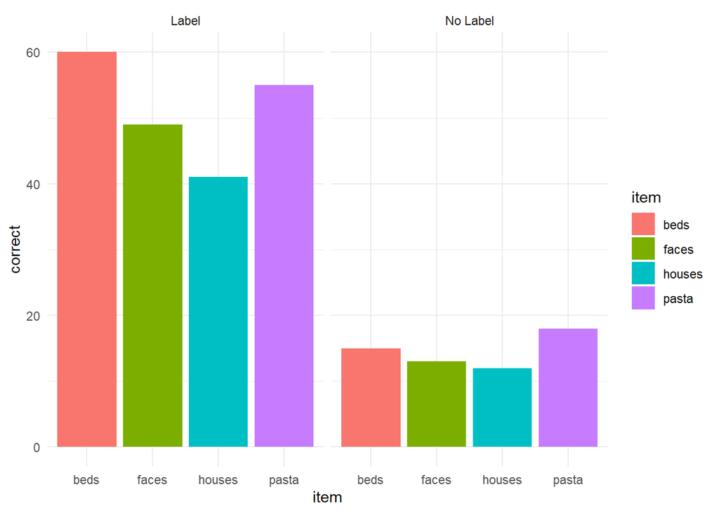

```r
ggplot(ps_data, aes(x = item, y = correct, fill = item)) +
  geom_bar(stat = "identity") +
  facet_wrap(~condition) +
  theme_minimal()
```

Or we could just as easily change it to `theme_linedraw()`:

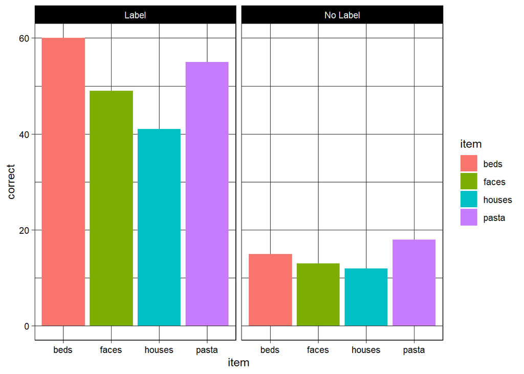

```r
ggplot(ps_data, aes(x = item, y = correct, fill = item)) +
  geom_bar(stat = "identity") +
  facet_wrap(~condition) +
  theme_linedraw()
```

### Exercise 3.3a

> Now I want you to explore the themes in ggplot2. Recreate whichever plot from today you want - or try to make a new one if you like - and try out different themes and find a favorite.

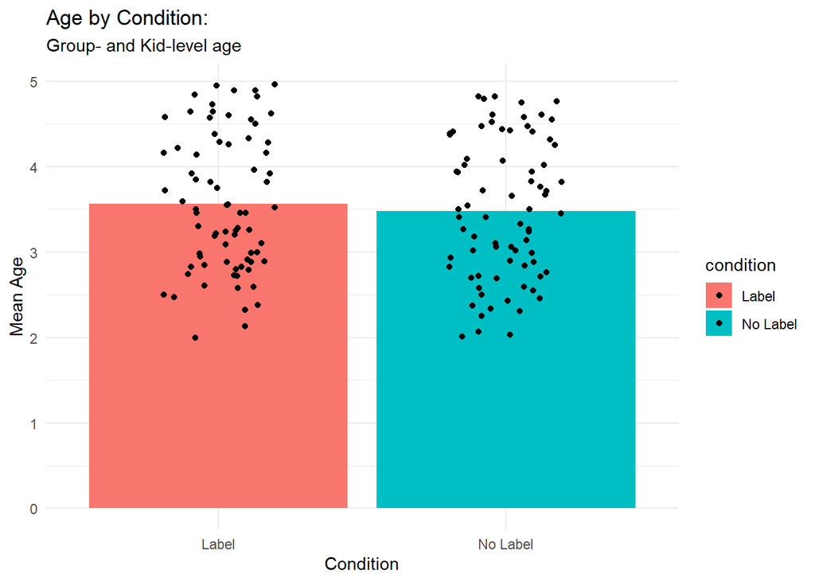

```r
ggplot(ps_mean_age, aes(x = condition, y = mean_age, fill = condition)) +
  geom_bar(stat = "identity") +
  geom_point(data = ps_distinct_age, aes(x = condition, y = age),
             position = position_jitter(height = 0, width = .2)) +
  # change labels with labs:
  labs(title = "Age by Condition:", # add a title with title
       subtitle = "Group- and Kid-level age", # you can even add a subtitle
       x = "Condition",
       y = "Mean Age") +
  theme_minimal()
```

## 3.4 Changing Scales

The last thing we’ll touch on in ggplot are scales. Scale set the parameters for how geoms are sized, colored, place, etc. Let’s take a look at one more dataset, the `diamonds` dataset:

```r
diamonds <- diamonds %>%
  sample_n(1000)
```

Let’s take a look at the relationship between a diamonds’ carat and its price. But first, let’s see how each is distributed:

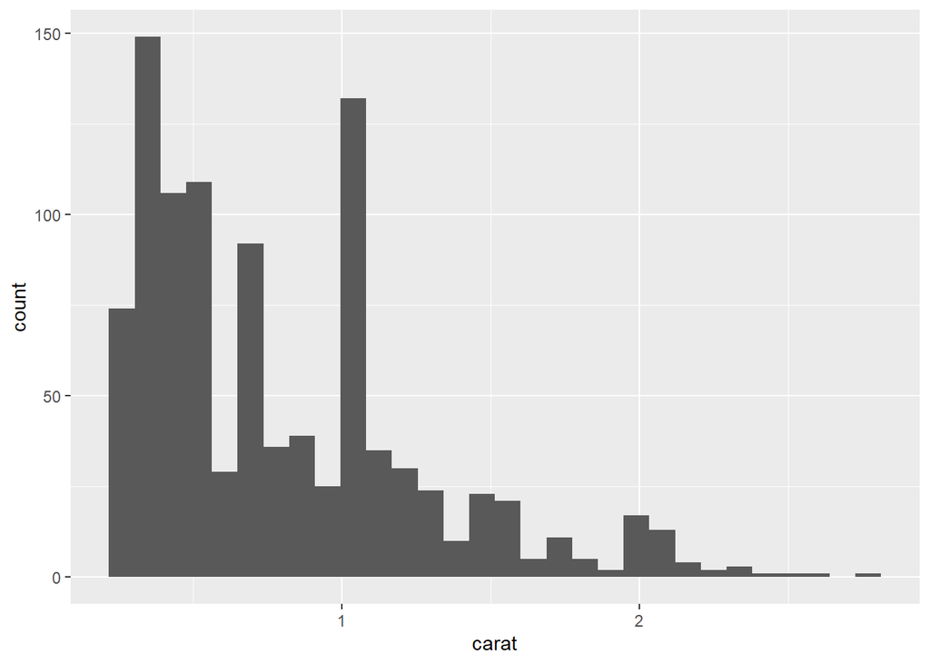

```r
ggplot(diamonds, aes(x = carat)) +
  geom_histogram()
```

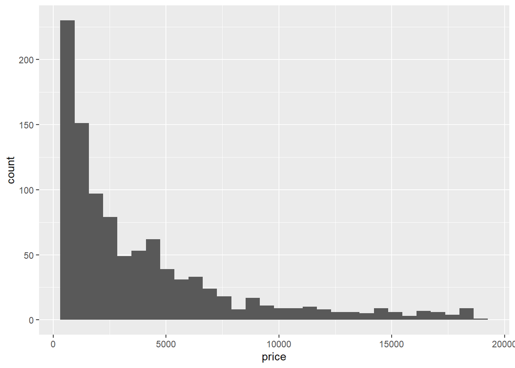

```r
ggplot(diamonds, aes(x = price)) +
  geom_histogram()
```

Looks like both variables are positively (right-) skewed. One solution is to log transform them, and we can do that pretty easily for our plot by changing the scale.

`ggplot2` has a number of scale options for all of its aesthetics. We’ll re-scale x and y using `scale_x_log10` and `scale_y_log10`:

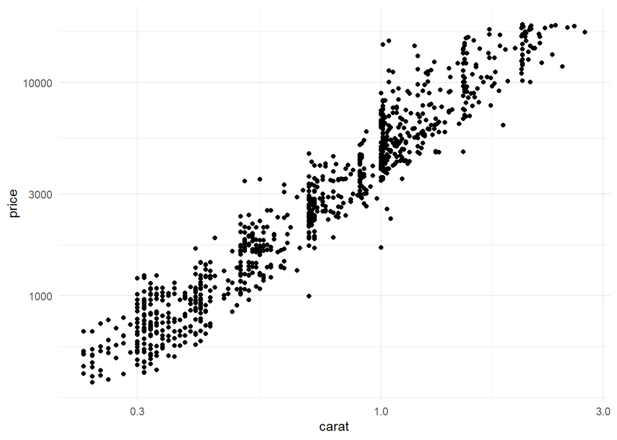

```r
ggplot(diamonds, aes(x = carat, y = price)) +
  geom_point() +
  theme_minimal() +
  scale_x_log10() +
  scale_y_log10()
```

You can also change the scale of other aesthetics too. For example, let’s color points by diamonds’ cut:

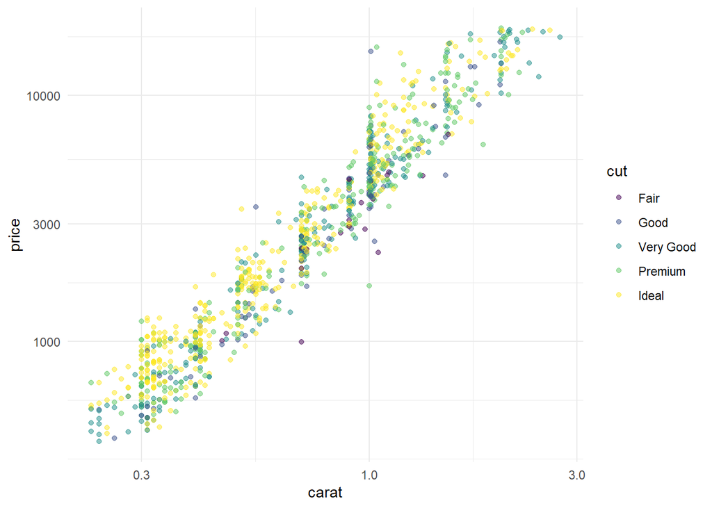

```r
ggplot(diamonds, aes(x = carat, y = price, color = cut)) +
  geom_point(alpha = .5) + # changing alpha bc of overlap
  theme_minimal() +
  scale_x_log10() +
  scale_y_log10()
```

And then we could change that using `scale_color_brewer()` and setting the pallete to something else. We can see its options by checking out the help documentation:

```r
?scale_color_brewer
```

Let’s set it to set1:

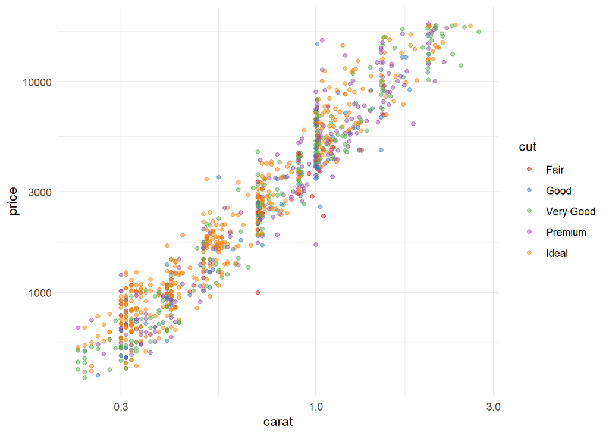

```r
ggplot(diamonds, aes(x = carat, y = price, color = cut)) +
  geom_point(alpha = .5) + # changing alpha bc of overlap
  theme_minimal() +
  scale_x_log10() +
  scale_y_log10() +
  scale_color_brewer(palette="Set1")
```

Or we could change it to another palette:

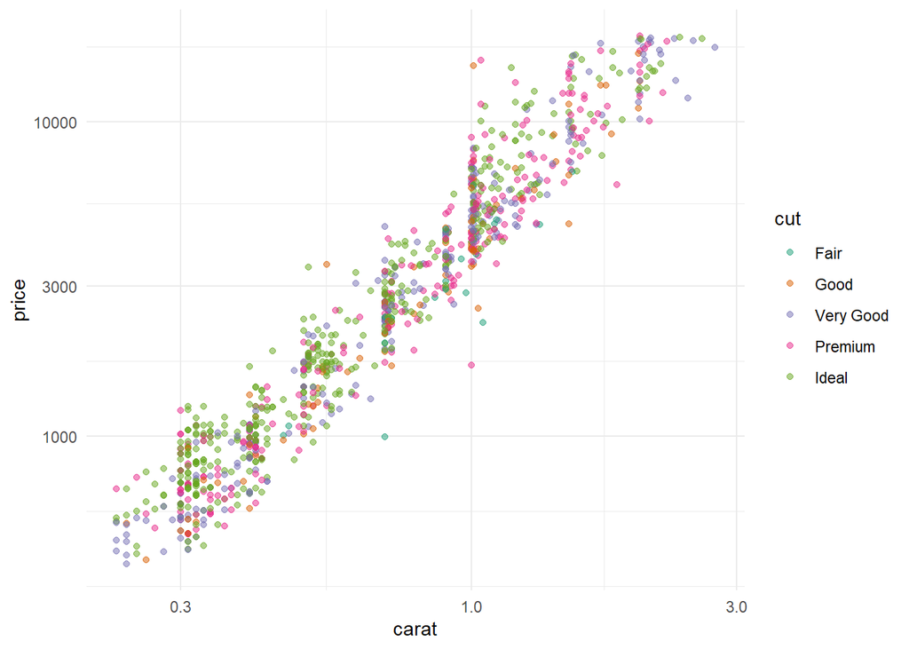

```r
ggplot(diamonds, aes(x = carat, y = price, color = cut)) +
  geom_point(alpha = .5) + # changing alpha bc of overlap
  theme_minimal() +
  scale_x_log10() +
  scale_y_log10() +
  scale_color_brewer(palette="Dark2")
```

# Final Exercise!

> For our last exercise, we’ll do something a little more fun. I want you to use the tools we’ve covered today to make the ugliest plot possible. Some things that might help:
> - Mixing unrelated datasets together using geom-level data
> - Using aesthetics in a weird way (e.g., aesthetically mapping size)
> - altering the theme

> Get creative and have fun with it! This is a great way to find out more about ggplot, and maybe find out some things you shouldn’t do (hint: try using geom_line()).